# Genotype comparison with USDA system

Sourced file contains genotype labels assigned by method described in Harvey *et al*. 2025 (https://doi.org/10.1101/2025.08.20.670882) and genotypes assigned by the USDA GenoFLU system (https://github.com/USDA-VS/GenoFLU) as presented linked to isolates downloaded from GISAID (https://gisaid.org).

```r
dat <- read.csv('genome_profiles_compare_genoFLU.csv')

dat <- dat[grepl('^H5N1', dat$genotype_label),]
dat <- dat[!grepl('^Minor', dat$USDA_genotype),]
dat <- dat[!dat$USDA_genotype %in% c('Notassigned'),]
dat <- dat[!is.na(dat$genotype_label),]
dat <- dat[!is.na(dat$USDA_genotype),]



tab <- as.data.frame(table(dat$genotype_label,
                        dat$USDA_genotype),
                     stringsAsFactors = F)
```

### Plot

Here, we generate plot showing degree of correspondence between genotype systems. Tiles are coloured by the number of genomes assigned to a genotype combination:

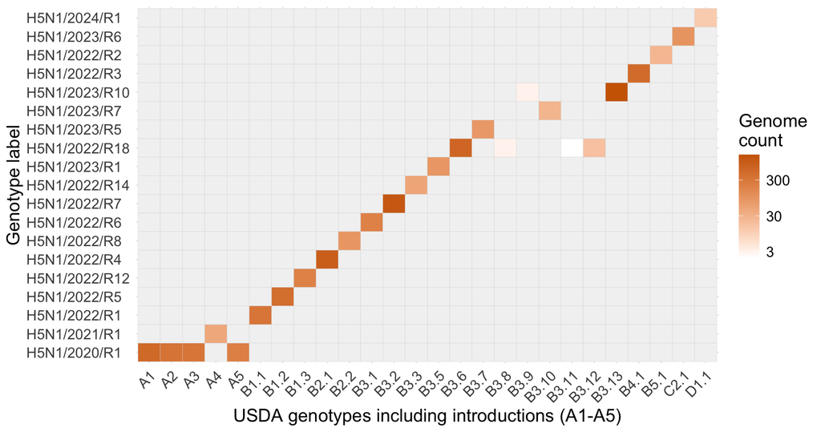

```r
ggplot(tab, aes(x = Var2, y = Var1, fill = Freq)) +
  geom_tile(col = 'grey85') +
  scale_fill_gradient(trans = 'log', breaks = c(3, 30, 300),
                      low = 'white', high = 'darkorange3',  na.value = 'grey95') +
  labs(x = 'USDA genotypes including introductions (A1-A5)',
       y = 'Genotype label',
       fill = 'Genome\ncount') +
  theme_minimal() +
  theme(text = element_text(size = 15),
        axis.text.x = element_text(angle = 45, hjust = 1),
        axis.text.y = element_text(hjust = 0))
```

```r
ggsave('genotype_compare.png', dpi = 320, bg = 'white', width = 9.5, height = 5)
```

Generally, genomes are assigned to one distinct genotype by both systems, though there are some exceptions. For example, a small number of genotypes assigned to genotypes B3.8, B3.11 and B3.12 are assigned to the label H5N1/2022/R18 in addition to B3.6 viruses which comprise the vast majority of H5N1/2022/R18 genomes.

For the USDA system, A-type genotypes (A1-A5 etc.) represent epidemiologically distinct introductions of H5N1 clade 2.3.4.4b into North America, B-type genotypes are inferred to be reassortants of the A1 genotype with North American viruses, C-types reassortants of the A2 genotype and so on. For further details, see Youk *et al*. 2023 (https://doi.org/10.1016/j.virol.2023.109860).